# MongoDB et Python

```python
from pymongo import MongoClient
import pandas as pd

import datetime
import pprint

from bioservices import QuickGO

from datetime import datetime
from bson.objectid import ObjectId
from collections import defaultdict
```

```python
s = QuickGO(verbose=False)

res = s.Annotation(geneProductId="P04637,P51587",includeFields="goName,taxonName,name,synonyms")
```

```python
res=res["results"]
for d in res:
    d.update((k, datetime.strptime(v,"%Y%m%d")) for k, v in d.items() if k == "date")
```

Un apercu des données.

```python
res[:2]
```

```
[{'_id': ObjectId('5a66e40979f75dd082aa61bb'),
  'assignedBy': 'BHF-UCL',
  'date': datetime.datetime(2009, 6, 17, 0, 0),
  'evidenceCode': 'ECO:0000314',
  'extensions': None,
  'geneProductId': 'UniProtKB:P04637',
  'goAspect': 'cellular_component',
  'goEvidence': 'IDA',
  'goId': 'GO:0005669',
  'goName': 'transcription factor TFIID complex',
  'id': 'UniProtKB:P04637!415151352',
  'interactingTaxonId': 0,
  'name': 'Cellular tumor antigen p53',
  'qualifier': 'colocalizes_with',
  'reference': 'PMID:15053879',
  'symbol': 'TP53',
  'synonyms': 'P53_HUMAN,TP53,P53',
  'targetSets': ['BHF-UCL', 'KRUK'],
  'taxonId': 9606,
  'taxonName': 'Homo sapiens',
  'withFrom': None},
 {'_id': ObjectId('5a66e40979f75dd082aa61bc'),
  'assignedBy': 'BHF-UCL',
  'date': datetime.datetime(2009, 12, 11, 0, 0),
  'evidenceCode': 'ECO:0000314',
  'extensions': None,
  'geneProductId': 'UniProtKB:P04637',
  'goAspect': 'cellular_component',
  'goEvidence': 'IDA',
  'goId': 'GO:0016604',
  'goName': 'nuclear body',
  'id': 'UniProtKB:P04637!415151353',
  'interactingTaxonId': 0,
  'name': 'Cellular tumor antigen p53',
  'qualifier': 'colocalizes_with',
  'reference': 'PMID:10360174',
  'symbol': 'TP53',
  'synonyms': 'P53_HUMAN,TP53,P53',
  'targetSets': ['BHF-UCL', 'KRUK'],
  'taxonId': 9606,
  'taxonName': 'Homo sapiens',
  'withFrom': None}]
```

### MongoDB [1](http://api.mongodb.com/python/current/tutorial.html),[2](http://api.mongodb.com/python/current/examples/index.html)

#### Connexion au serveur

Tout d'abord, exécuter le client mongo depuis votre terminal. Par défaut, il se connecte au serveur mongod en localhost sur le port 27017.

```python
client = MongoClient('localhost:27017')
client
```

```
MongoClient(host=['localhost:27017'], document_class=dict, tz_aware=False, connect=True)
```

#### Création d'une base de donnée

Une fois connecté au serveur, il est possible d'accéder aux bases de données. MongoDB crée des bases et des collections automatiquement si elles n'existent pas déjà. Une seule instance MongoDB peut gérer de multiples bases de données indépendantes. En utilisant PyMongo, on accède ou accède au bases de données de la façon suivante:

```python
db = client['GoTerm_database']
db
```

```
Database(MongoClient(host=['localhost:27017'], document_class=dict, tz_aware=False, connect=True), 'GoTerm_database')
```

Il est possible de connaitre les bases de données disponibles en utilisant la méthode *database_names()*.NB: les bases de données sans collections ou contenant des collections vides ne seront aps affichées.

```python
client.database_names()
```

```
['GoTerm_database', 'admin', 'config', 'local']
```

#### Les collections

Une collection est un ensemble de document et peut être vu comme une table dans une base de données relationnelle. Les collections et les bases sont créées de façon "lazy" c'est-à-dire quand le premier document est inséré. Enfin, MongoDB intègre des index notés _id unique pour chaque document.

```python
collection = db['ontology']
db.collection_names()
```

```
['ontology']
```

#### Insertion de documents

Afin d'insérer un document dans une collection, nous pouvons utiliser la méthode *insert_one()*:

```python
post = res[0]
collection.insert_one(post)
collection
```

[output not shown]

De plus, afin d'insérer une série de document il est possible d'utiliser la méthode *insert_many()* qui prend en argument une liste. Cela insérera chaque document contenu dans la liste.

```python
collection.insert_many(res)
```

```
<pymongo.results.InsertManyResult at 0xb2ab308>
```

### Requêter les données

#### Lecture

L'une des principales opérations qu'il est nécessaire de connaitre est de retrouver les données contenues dans les bases. L'objet connection fourni alors 2 méthodes *find_one()* et *find()*:

- La méthode find_one() extrait et retourner un unique document de la collection. Elle est utile quand nous souhaitons n'extraire qu'un résultat, ou le premier résultat matchant al condition passée en argument:

```python
pprint.pprint(collection.find_one())
```

```
{'_id': ObjectId('5a66e40979f75dd082aa61bb'),
 'assignedBy': 'BHF-UCL',
 'date': datetime.datetime(2009, 6, 17, 0, 0),
 'evidenceCode': 'ECO:0000314',
 'extensions': None,
 'geneProductId': 'UniProtKB:P04637',
 'goAspect': 'cellular_component',
 'goEvidence': 'IDA',
 'goId': 'GO:0005669',
 'goName': 'transcription factor TFIID complex',
 'id': 'UniProtKB:P04637!415151352',
 'interactingTaxonId': 0,
 'name': 'Cellular tumor antigen p53',
 'qualifier': 'colocalizes_with',
 'reference': 'PMID:15053879',
 'symbol': 'TP53',
 'synonyms': 'P53_HUMAN,TP53,P53',
 'targetSets': ['BHF-UCL', 'KRUK'],
 'taxonId': 9606,
 'taxonName': 'Homo sapiens',
 'withFrom': None}
```

- La méthode find() fonctionne comme la mééthode find_one() tandis qu'elle retourner tous les documents matchant la condition passée en argument. La commande ci-dessous renverrait tous les documents (et itérerait sur chacun d'entre-eux) si nous n'avions pas commandé l'extraction des deux premiers.

```python
for post in collection.find()[:2]:
    pprint.pprint(post)
```

```
{'_id': ObjectId('5a66e40979f75dd082aa61bb'),
 'assignedBy': 'BHF-UCL',
 'date': datetime.datetime(2009, 6, 17, 0, 0),
 'evidenceCode': 'ECO:0000314',
 'extensions': None,
 'geneProductId': 'UniProtKB:P04637',
 'goAspect': 'cellular_component',
 'goEvidence': 'IDA',
 'goId': 'GO:0005669',
 'goName': 'transcription factor TFIID complex',
 'id': 'UniProtKB:P04637!415151352',
 'interactingTaxonId': 0,
 'name': 'Cellular tumor antigen p53',
 'qualifier': 'colocalizes_with',
 'reference': 'PMID:15053879',
 'symbol': 'TP53',
 'synonyms': 'P53_HUMAN,TP53,P53',
 'targetSets': ['BHF-UCL', 'KRUK'],
 'taxonId': 9606,
 'taxonName': 'Homo sapiens',
 'withFrom': None}
{'_id': ObjectId('5a66e40979f75dd082aa61bc'),
 'assignedBy': 'BHF-UCL',
 'date': datetime.datetime(2009, 12, 11, 0, 0),
 'evidenceCode': 'ECO:0000314',
 'extensions': None,
 'geneProductId': 'UniProtKB:P04637',
 'goAspect': 'cellular_component',
 'goEvidence': 'IDA',
 'goId': 'GO:0016604',
 'goName': 'nuclear body',
 'id': 'UniProtKB:P04637!415151353',
 'interactingTaxonId': 0,
 'name': 'Cellular tumor antigen p53',
 'qualifier': 'colocalizes_with',
 'reference': 'PMID:10360174',
 'symbol': 'TP53',
 'synonyms': 'P53_HUMAN,TP53,P53',
 'targetSets': ['BHF-UCL', 'KRUK'],
 'taxonId': 9606,
 'taxonName': 'Homo sapiens',
 'withFrom': None}
```

#### Comptage

Combien de document il y a-t-il dans la collection? Combiend de document correspondent à al requête? La méthode *count()* réponds à ces questions. Nous comptons ci-dessous combien de documents contient la collection.

```python
collection.count()
```

```
100
```

#### Conditions

Les requêtes MongoDB sont représentées comme une structure JSON. Pour construire une requête, il suffit juste de spécifier un dictionnaire contenant les propriétés que nous souhaitons retrouver.

```python
mf=collection.find({"goAspect": "molecular_function"}).count()
cc=collection.find({"goAspect": "cellular_component"}).count()
bp=collection.find({"goAspect": "biological_process"}).count()
print(" Il y a {} GO term annotés  Molecular Function, {} Cellular Component et {} Biological Process".format(mf,cc,bp))
```

```
 Il y a 98 GO term annotés  Molecular Function, 2 Cellular Component et 0 Biological Process
```

#### Les opérateurs de requêtes

Les requêtes peuvent également faire appel aux opérateurs. Ces opérateurs sont notamment gt, gte, lt, lte, ne, nin, regex, exists, not, or, et [bien d'autres](https://docs.mongodb.com/manual/reference/operator/query/) . La requête suivante ira extraire tous les GO term antérieur au 11 Juillet 2007.

*NB: Nous avons converti les éléments dates du json afin d'en faire des objets datetime, aisément manipulable en python*

```python
date = datetime.strptime("11/07/2007", "%d/%m/%Y")
_=collection.find({"date": {"$lt":date}}).count()
print("Il y a {} GO term antérieurs au 11 Juillet 2007".format(_))
```

```
Il y a 16 GO term antérieurs au 11 Juillet 2007
```

Extraction des GO term dont le "qualifier" n'est pas "enables"

```python
for post in collection.find({"qualifier":{"$nin":["enables"]}}):
    pprint.pprint(post)
```

```
{'_id': ObjectId('5a6618bd79f75da856687485'),
 'assignedBy': 'BHF-UCL',
 'date': datetime.datetime(2009, 6, 17, 0, 0),
 'evidenceCode': 'ECO:0000314',
 'extensions': None,
 'geneProductId': 'UniProtKB:P04637',
 'goAspect': 'cellular_component',
 'goEvidence': 'IDA',
 'goId': 'GO:0005669',
 'goName': 'transcription factor TFIID complex',
 'id': 'UniProtKB:P04637!415151352',
 'interactingTaxonId': 0,
 'name': 'Cellular tumor antigen p53',
 'qualifier': 'colocalizes_with',
 'reference': 'PMID:15053879',
 'symbol': 'TP53',
 'synonyms': 'P53_HUMAN,TP53,P53',
 'targetSets': ['BHF-UCL', 'KRUK'],
 'taxonId': 9606,
 'taxonName': 'Homo sapiens',
 'withFrom': None}
{'_id': ObjectId('5a6618bd79f75da856687486'),
 'assignedBy': 'BHF-UCL',
 'date': datetime.datetime(2009, 12, 11, 0, 0),
 'evidenceCode': 'ECO:0000314',
 'extensions': None,
 'geneProductId': 'UniProtKB:P04637',
 'goAspect': 'cellular_component',
 'goEvidence': 'IDA',
 'goId': 'GO:0016604',
 'goName': 'nuclear body',
 'id': 'UniProtKB:P04637!415151353',
 'interactingTaxonId': 0,
 'name': 'Cellular tumor antigen p53',
 'qualifier': 'colocalizes_with',
 'reference': 'PMID:10360174',
 'symbol': 'TP53',
 'synonyms': 'P53_HUMAN,TP53,P53',
 'targetSets': ['BHF-UCL', 'KRUK'],
 'taxonId': 9606,
 'taxonName': 'Homo sapiens',
 'withFrom': None}
```

### Aggregation [1](http://api.mongodb.com/python/current/examples/aggregation.html),[2](https://www.compose.com/articles/aggregations-in-mongodb-by-example/),[3](https://gist.github.com/alain-andre/8150256)

Les opérations d'aggrégations s'exécutent directement sur les données et retourne un résultat de type collection. Ces opérations "regroupent" ensembles les valeurs de multiples documents, et peuvent également procéder à une large variété d'opérations. Les plus pertinentes sont présentées ici.

#### $group

Permet de faire un group by SQL et ainsi de retrouver le nombre de X disponibles pour chaque Y.

```python
pipeline = [{"$group": {"_id": "$goAspect", "count": {"$sum": 1}}}]
pprint.pprint(list(collection.aggregate(pipeline)))
```

```
[{'_id': 'molecular_function', 'count': 98},
 {'_id': 'cellular_component', 'count': 2}]
```

#### $match

Recherche dans la collection. Dans ce cas nous extrayons les GO term "Molecular Function" puis nous les regroupons par goName afin de procéder à un comptage.

```python
pipeline = [{
    "$match": {
      "goAspect": "molecular_function"
    }
  },{"$group": {"_id": "$goName", "count": {"$sum": 1}}}]
pprint.pprint(list(collection.aggregate(pipeline)))
```

```
[{'_id': 'protein binding', 'count': 69},
 {'_id': "mRNA 3'-UTR binding", 'count': 1},
 {'_id': 'DNA binding transcription factor activity', 'count': 4},
 {'_id': 'chromatin binding', 'count': 2},
 {'_id': 'transcriptional activator activity, RNA polymerase II transcription '
         'regulatory region sequence-specific DNA binding',
  'count': 1},
 {'_id': 'transcription factor activity, TFIID-class binding', 'count': 1},
 {'_id': 'core promoter sequence-specific DNA binding', 'count': 2},
 {'_id': 'TFIID-class transcription factor binding', 'count': 1},
 {'_id': 'transcription cofactor binding', 'count': 1},
 {'_id': 'RNA polymerase II transcription factor activity, sequence-specific '
         'DNA binding',
  'count': 2},
 {'_id': 'p53 binding', 'count': 2},
 {'_id': 'damaged DNA binding', 'count': 1},
 {'_id': 'copper ion binding', 'count': 1},
 {'_id': 'RNA polymerase II transcription factor binding', 'count': 1},
 {'_id': 'transcription factor activity, core RNA polymerase binding',
  'count': 1},
 {'_id': 'RNA polymerase II regulatory region sequence-specific DNA binding',
  'count': 1},
 {'_id': 'DNA binding', 'count': 5},
 {'_id': 'transcription factor activity, RNA polymerase II proximal promoter '
         'sequence-specific DNA binding involved in preinitiation complex '
         'assembly',
  'count': 1},
 {'_id': 'protease binding', 'count': 1}]
```

#### $project

Permet de remodeler une collection. Dans le cas ci-dessous nous nous contentons de mettre en majuscule tous les identifiants "qualifier" dont le goAspect est *cellular_component*, mais n'importe qu'elle fonction peut être appliquée sur les données.

```python
pipeline=[
    {
    "$match": {
      "goAspect": "cellular_component"
    }
  },
  { "$project":
    {
      "_id": "$goAspect",
      "qualifier": {"$toUpper": "$qualifier" },
    }
  }
]
pprint.pprint(list(collection.aggregate(pipeline)))
```

```
[{'_id': 'cellular_component', 'qualifier': 'COLOCALIZES_WITH'},
 {'_id': 'cellular_component', 'qualifier': 'COLOCALIZES_WITH'}]
```

```python
collection.find().count()
```

```
100
```

### Tri

MongoDB peut trier les requêtes.

```python
results=collection.find().sort([("date", -1)])
for post in results[:2]:
    print(post,end="\n\n")
```

```
{'_id': ObjectId('5a6618bd79f75da8566874a4'), 'id': 'UniProtKB:P04637!415151383', 'geneProductId': 'UniProtKB:P04637', 'qualifier': 'enables', 'goId': 'GO:0005515', 'goName': 'protein binding', 'goEvidence': 'IPI', 'goAspect': 'molecular_function', 'evidenceCode': 'ECO:0000353', 'reference': 'PMID:1…

{'_id': ObjectId('5a6618bd79f75da8566874a5'), 'id': 'UniProtKB:P04637!415151384', 'geneProductId': 'UniProtKB:P04637', 'qualifier': 'enables', 'goId': 'GO:0005515', 'goName': 'protein binding', 'goEvidence': 'IPI', 'goAspect': 'molecular_function', 'evidenceCode': 'ECO:0000353', 'reference': 'PMID:1…
```

### Mise à jour

#### Mettre à jour un document d'une collection

PyMongo peut mettre à jour les documents d'une collection. Pour voir le nombre de documents qui ont matché la condition, l'attribut *matched_count* peut être utilisé sur l'objet. En revanche pour voir le nombre de document *mis à jour* par l'opération, l'attribut *modified_count* peut être utilisé.

```python
result=collection.update_one({'id': 'UniProtKB:P04637!415151353'},
                     {
                         "$set":{
                             'goName': 'Changement de GoName'
                         }

                     })
result.matched_count
result.modified_count

for post in collection.find({'id': 'UniProtKB:P04637!415151353'}):
    print(post)
```

```
{'_id': ObjectId('5a6618bd79f75da856687486'), 'id': 'UniProtKB:P04637!415151353', 'geneProductId': 'UniProtKB:P04637', 'qualifier': 'colocalizes_with', 'goId': 'GO:0016604', 'goName': 'Changement de GoName', 'goEvidence': 'IDA', 'goAspect': 'cellular_component', 'evidenceCode': 'ECO:0000314', 'refer…
```

#### Mettre à jour plusieurs documents d'une collection

```python
result=collection.update_many({'goAspect': 'cellular_component'},
                     {
                         "$set":{
                             'taxonName': 'Homo erectus'
                         }

                     })
print("Matched count {}".format(result.matched_count))
print("Modified count {}".format(result.modified_count))

for post in collection.find({'goAspect': 'cellular_component'})[:10]:
    print(post)
```

```
Matched count 2
Modified count 0
{'_id': ObjectId('5a6618bd79f75da856687485'), 'id': 'UniProtKB:P04637!415151352', 'geneProductId': 'UniProtKB:P04637', 'qualifier': 'colocalizes_with', 'goId': 'GO:0005669', 'goName': 'transcription factor TFIID complex', 'goEvidence': 'IDA', 'goAspect': 'cellular_component', 'evidenceCode': 'ECO:00…
{'_id': ObjectId('5a6618bd79f75da856687486'), 'id': 'UniProtKB:P04637!415151353', 'geneProductId': 'UniProtKB:P04637', 'qualifier': 'colocalizes_with', 'goId': 'GO:0016604', 'goName': 'Changement de GoName', 'goEvidence': 'IDA', 'goAspect': 'cellular_component', 'evidenceCode': 'ECO:0000314', 'refer…
```

#### Remplacer un document d'une collection

```python
result = collection.replace_one(
    {"id": "UniProtKB:P04637!415151353"},
    {
        "nom": "Master BIMS",
        "addresse": {
            "coord": [-73.9557413, 40.7720266],
            "street": "Place Emile Blondel",
            "zipcode": "76"
        }
    }
)
print("Matched count {}".format(result.matched_count))
print("Modified count {}".format(result.modified_count))
```

```
Matched count 1
Modified count 1
```

```python
for post in collection.find({"_id":ObjectId('5a66e40979f75dd082aa61bb')}):
    print(post)
```

```
{'_id': ObjectId('5a66e40979f75dd082aa61bb'), 'nom': 'Master BIMS', 'addresse': {'coord': [-73.9557413, 40.7720266], 'street': 'Place Emile Blondel', 'zipcode': '76'}}
```

### Indexation

Comme dans MySQL, les index permettent d’accélérer les requêtes en évitant au moteur de base de données de devoir scanner tous les documents de la collection afin de trouver ceux correspondant à la requête.

```python
collection.create_index([('goId','text')], name='goId_index')
collection.index
```

```
Collection(Database(MongoClient(host=['localhost:27017'], document_class=dict, tz_aware=False, connect=True), 'GoTerm_database'), 'ontology.index')
```

### Suppression

#### Supprimer tous les documents matchant une condition

```python
result = collection.delete_many({'goAspect': 'cellular_component'})
result.deleted_count
```

```
1
```

#### Supprimer tous les documents

```python
result = collection.delete_many({})
result.deleted_count
```

[output not shown]

```python
collection.find().count()
```

[output not shown]

#### Supprimer une collection

```python
collection.drop()
```

### Représentations de la collection

La possibilité d'exploiter MongoDB avec Python nous permet également de directement manipuler les bases de données puis de les analyser (analyses statistiques, visualisation,etc). Par exemple, nous pouvons explorer notre collection en utilisant le module pandas.

```python
%matplotlib inline
```

Et voir les GO les plus représentés dans la base de données.

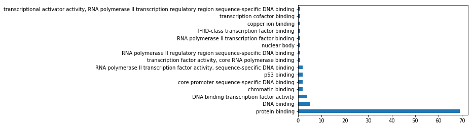

```python
df = pd.DataFrame(list(collection.find()))
df["goName"].value_counts()[:15].plot(kind="barh")
```

Ou visualiser rapidement la répartition des GO Aspect.

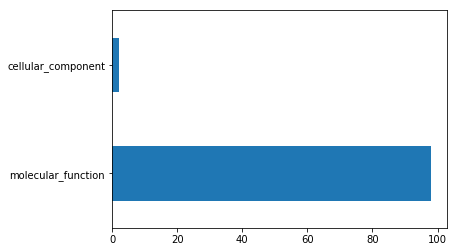

```python
df["goAspect"].value_counts().plot(kind="barh")
```

```python
df.head(1)
```

|  | _id | assignedBy | date | evidenceCode | extensions | geneProductId | goAspect | goEvidence | goId | goName | ... | interactingTaxonId | name | qualifier | reference | symbol | synonyms | targetSets | taxonId | taxonName | withFrom |
| --- | --- | --- | --- | --- | --- | --- | --- | --- | --- | --- | --- | --- | --- | --- | --- | --- | --- | --- | --- | --- | --- |
| 0 | 5a66e40979f75dd082aa61bb | BHF-UCL | 2009-06-17 | ECO:0000314 | None | UniProtKB:P04637 | cellular_component | IDA | GO:0005669 | transcription factor TFIID complex | ... | 0 | Cellular tumor antigen p53 | colocalizes_with | PMID:15053879 | TP53 | P53_HUMAN,TP53,P53 | [BHF-UCL, KRUK] | 9606 | Homo sapiens | None |

1 rows × 21 columns